# Regresión lineal simple

Debes tener la habilidad de modelar ciertos problemas, por ello debes saber como funciona la regresión lineal

# Ejemplo

Digamos que te contratan como empleado y te dan una relación de datos entre gastos de publicidad y ganancias en $US.

| Gasto $K$$ | Ganancia $K$$ |
| --- | --- |
| 1.2 | 2 |
| 2 | 3 |
| 3.2 | 3.4 |
| 2.5 | 3.1 |
| 5 | 4 |
| 6 | 4.7 |
| 4 | 3.8 |
| 8 | 7 |

Despues me pide que elabore un modelo para predecir **¿cuanto voy a ganar o cuanto voy a gastar?**

```python
import numpy as np
import matplotlib.pyplot as plt

#Configurando Latex
# Configuración de Matplotlib para usar LaTeX
plt.rcParams.update({
    "text.usetex": True,
    "font.family": "serif",
    "font.serif": ["Computer Modern Roman"],
    "text.latex.preamble": r"\usepackage{amsmath}"
})
```

```
No artists with labels found to put in legend.  Note that artists whose label start with an underscore are ignored when legend() is called with no argument.
```

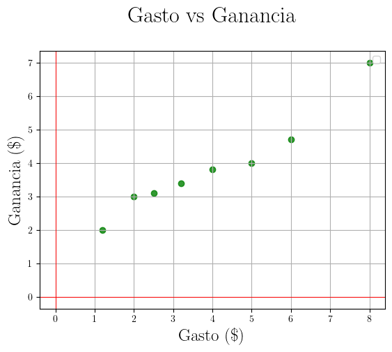

```python
#Planteando el problema en código
gasto=np.array([1.2,2,3.2,2.5,5,6,4,8])
ganancia = np.array([2,3,3.4,3.1,4,4.7,3.8,7])

#Creando graficas
fig, ax = plt.subplots()
ax.scatter(gasto,ganancia,color='green',alpha=0.8)
ax.grid()
ax.axhline(y=0, color='r',linewidth=.7)
ax.axvline(x=0, color='r',linewidth=.7)
plt.title('Gasto vs Ganancia\n',fontsize=23)
plt.xlabel(r'Gasto $(\$)$',fontsize=18)
plt.ylabel(r'Ganancia $(\$)$',fontsize=18)
plt.legend()
plt.show()
```

Por eso es tan importante que aprendas a modelar funciones o sepas como se van a estar comportando los datos.

Una función que nos puede ayudar a ver como se comportan los datos es una linea recta.

En donde obtenemos a $b$ cuando $x=0$, entonces podemos decir que $b=f(0)$. Recordemos que la ecuación es: $$y=mx+b$$
Pero hay un problema y es que hay muchas lineas rectas que pueden pasar por los puntos. Entonces **¿cómo podemos saber que linea es la adecuada?** **¿Cómo podemos decir si es mejor una a otra?**

Tal vez deberiamos medir que tan equivocados estamos, entonces para eso se crean otro tipo de funciones llamadas **funciones de error**. Veamoslo en la siguiente.

## Extras:

- [Regresión lineal](https://www.youtube.com/watch?v=5TcA5M5z4sA)
- [Regresión lineal](https://www.youtube.com/watch?v=k964_uNn3l0)